# CIND830W21_A1

## CIND830 - Python Programming for Data Science

### Assignment 1 (10% of the final grade)

### Due on February 8, 2021 11:59 PM

This is a Jupyter Notebook document that extends a simple formatting syntax for authoring HTML and PDF. Review [this](https://jupyter-notebook.readthedocs.io/en/stable/notebook.html) website for more details on using Jupyter Notebook.

Use the JupyterHub server on the Google Cloud Platform, provided by your designated instructor, for this assignment. Ensure using **Python 3.7.6** release then complete the assignment by inserting your Python code wherever seeing the string "#INSERT YOUR ANSWER HERE."

When you click the `File` button, from the top navigation bar, then select `Export Notebook As ...`, a document (PDF or HTML format) will be generated that includes both the assignment content and the output of any embedded Python code chunks.

Using [these](https://www.ryerson.ca/courses/students/tutorials/assignments/) guidelines, submit **both** the IPYNB and the exported file (PDF or HTML). Failing to submit both files will be subject to mark deduction.

### Question 1 **[60 pts]**:

A multi-valued function has been defined as follows

$$ f(x) = \left\{ \begin{array}\\ ({\frac{x^2}{|x|+2}})^2 & \mbox{if} \ x < 5 \\ {\frac{x^2}{|x|+2}} & \mbox{if} \ x = 5 \\ \sqrt{\frac{x^2}{|x|+2} } & \mbox{if} \ x > 5 \end{array} \right. $$

**a)** **[10 pts]** Write a program to ask the user to enter a floating-point real number, check whether the number is greater, equal or less than 5, then print the output according to the definition of the multi-valued function.

For example, if the user enters `x = -57.8`, then the output should be:  
`The value of f(x) is 3121.1093571660267`

Hint: Use the `math` module as it provides access to some of the essential mathematical functions.

```python
import math
multifunction = float(input("Enter a vaule for x\n"))
if (multifunction < 5):
    v1=math.pow(((multifunction**2)/((abs(multifunction))+2)),2)
    print("The value for f(x) is\t",str(v1))
elif (multifunction == 5):
    v2=((multifunction**2)/((abs(multifunction))+2))
    print("The value for f(x) is\t",str(v2))
else:
    v3=math.pow(((multifunction**2)/((abs(multifunction))+2)),1/2)
    print("The value for f(x) is\t",str(v3))
```

```
The value for f(x) is	 3121.1093571660267
```

**b)** **[10 pts]** Round the output of Q1.a to the nearest ineteger, convert that integer to a list of digits, then print the result.

For example, if the user enters `x = -57.8`, then the output should be:  
`The value of f(x) is 3121.1093571660267`  
`The list of digits is [3, 1, 2, 1]`

```python
import math
multifunction = float(input("Enter a value for x\n"))
if (multifunction < 5):
    v1=math.pow(((multifunction**2)/((abs(multifunction))+2)),2)
    print("The value for f(x) is\t",str(v1))
    res1 = list(map(int, str((math.floor(v1)))))
    print("The list of digits is"+ str(res1))
elif (multifunction == 5):
    v2=((multifunction**2)/((abs(multifunction))+2))
    print("The value for f(x) is\t",str(v2))
    res2 = list(map(int, str((math.floor(v2)))))
    print("The list of digits is"+ str(res2))
else:
    v3=math.pow(((multifunction**2)/((abs(multifunction))+2)),1/2)
    print("The value for f(x) is\t",str(v3))
    res3 = list(map(int, str((math.floor(v3)))))
    print("The list of digits is"+ str(res3))
```

```
The value for f(x) is	 3121.1093571660267
The list of digits is[3, 1, 2, 1]
```

**c)** **[10 pts]** Find and print the `Median`, `Average` and `Mode` of the generated list in Q1.b. For example, having `list = [6, 7, 7, 4]`, the result should be `Median = 6.5; Average = 6; Mode = 7`. Ensure notifying the user if there is no unique mode found, as the `Mode` in this exercise returns only the single most common data item in the list.

For example, if the user enters `x = -57.8`, then the output should be:  
`The value of f(x) is 3121.1093571660267`  
`The list of digits is [3, 1, 2, 1]`  
`Median is 1.5 ; Average is 1.75 ; Mode = 1`

However, if the user enters `x = -57.2`, then the output should be:  
`The value of f(x) is 3054.5040248356463`  
`The list of digits is [3, 0, 5, 4]`  
`Median is 3.5 ; Average is 3 ; No unique mode found`

Hint: Use the `statistics` module as it provides functions to calculate mathematical statistics of numeric data.

```python
import math
import statistics
x = float(input("Enter a floating-point real number: "))

if x < 5 :
    result = math.pow(((x**2)/((abs(x))+2)),2)
elif x == 5:
    result = ((x**2)/((abs(x))+2))
elif x > 5:
    result = math.pow(((x**2)/((abs(x))+2)),1/2)

print("\nThe value of f(x) is", result)
numbers = []
int_result = int(result)
str_result = str(int_result)

for digit in str_result:
    numbers.append(int(digit))
print("\nThe list of digits is", numbers)

median = statistics.median(numbers)
avg = statistics.mean(numbers)

flag = False
for digit in numbers:

    if numbers.count(digit) >= 2:
        flag = True
        break

if flag == True:
    mode = statistics.mode(numbers)
    print("\nMedian is",median,"; Average is",avg,"; Mode =",mode)
else:
    print("\nMedian is",median,"; Average is",avg,"; No unique mode found")
```

```
The value of f(x) is 3054.5040248356463

The list of digits is [3, 0, 5, 4]

Median is 3.5 ; Average is 3 ; No unique mode found
```

**d)** **[10 pts]** Find and print the sum of squares of all the numbers of the list generated in Q1.b.

For example, if the user enters `x = -57.8`, then the output should be:  
`The value of f(x) is 3121.1093571660267`  
`The list of digits is [3, 1, 2, 1]`  
`The sum of squares is 15`

```python
import math
def squarefunction(num):
    return(num*num)
multifunction = float(input("Enter a value for x\n"))
if (multifunction < 5):
    v1=math.pow(((multifunction**2)/((abs(multifunction))+2)),2)
    print("The value for f(x) is\t",str(v1))
    res1 = list(map(int, str((math.floor(v1)))))
    print("The list of digits is\t"+ str(res1))
    map_result1 = map(squarefunction, res1)
    ss1=sum(map_result1)
    print(" The sum of squares is\t",ss1)
elif (multifunction == 5):
    v2=((multifunction**2)/((abs(multifunction))+2))
    print("The value for f(x) is\t",str(v2))
    res2 = list(map(int, str((math.floor(v2)))))
    print("The list of digits is\t"+ str(res2))
    map_result2 = map(squarefunction, res2)
    ss2=sum(map_result2)
    print(" The sum of squares is\t",ss2)
else:
    v3=math.pow(((multifunction**2)/((abs(multifunction))+2)),1/2)
    print("The value for f(x) is\t",str(v3))
    res3 = list(map(int, str((math.floor(v3)))))
    print("The list of digits is\t"+ str(res3))
    map_result3 = map(squarefunction, res3)
    ss3=sum(map_result3)
    print(" The sum of squares is\t",ss3)
```

```
The value for f(x) is	 3121.1093571660267
The list of digits is	[3, 1, 2, 1]
 The sum of squares is	 15
```

**e)** **[10 pts]** Find and print the least common multiple of the numbers in the list generated in Q1.b.

For example, if the user enters `x = -57.8`, then the output should be:  
`The value of f(x) is 3121.1093571660267`  
`The list of digits is [3, 1, 2, 1]`  
`The least common multiple is 6`

```python
import math
def LCMofArray(a):
  lcm = a[0]
  for i in range(1,len(a)):
    lcm = lcm*a[i]//math.gcd(lcm, a[i])
  return lcm
multifunction = float(input("Enter a value for x\n"))
if (multifunction < 5):
    v1=math.pow(((multifunction**2)/((abs(multifunction))+2)),2)
    print("The value for f(x) is\t",str(v1))
    res1 = list(map(int, str((round(v1)))))
    print("The list of digits is\t"+ str(res1))
    print("The least common multiple is\t", LCMofArray(res1))
elif (multifunction == 5):
    v2=((multifunction**2)/((abs(multifunction))+2))
    print("The value for f(x) is\t",str(v2))
    res2 = list(map(int, str((round(v2)))))
    print("The list of digits is"+ str(res2))
    print("The least common multiple is\t", LCMofArray(res2))
else:
    v3=math.pow(((multifunction**2)/((abs(multifunction))+2)),1/2)
    print("The value for f(x) is\t",str(v3))
    res3 = list(map(int, str((round(v3)))))
    print("The list of digits is"+ str(res3))
    print("The least common multiple is\t", LCMofArray(res3))
```

```
The value for f(x) is	 3121.1093571660267
The list of digits is	[3, 1, 2, 1]
The least common multiple is	 6
```

**f)** **[10 pts]** Find and print the binary rpresentation of the numbers in the list generated in Q1.b.

For example, if the user enters `x = -57.8`, then the output should be:  
`The value of f(x) is 3121.1093571660267`  
`The list of digits is [3, 1, 2, 1]`  
`The binary representation is ['11', '1', '10', '1']`

```python
import math
multifunction = float(input("Enter a value for x\n"))
if (multifunction < 5):
    v1=math.pow(((multifunction**2)/((abs(multifunction))+2)),2)
    print("The value for f(x) is\t",str(v1))
    res1 = list(map(int, str((round(v1)))))
    print("The list of digits is\t"+ str(res1))
    b1= [str(bin(x))[2:].zfill(1) for x in res1]
    print("The binary representation is\t"+str(b1))
elif (multifunction == 5):
    v2=((multifunction**2)/((abs(multifunction))+2))
    print("The value for f(x) is\t",str(v2))
    res2 = list(map(int, str((round(v2)))))
    print("The list of digits is\t"+ str(res2))
    b2= [str(bin(x))[2:].zfill(1) for x in res2]
    print("The binary representation is\t"+str(b2))
else:
    v3=math.pow(((multifunction**2)/((abs(multifunction))+2)),1/2)
    print("The value for f(x) is\t",str(v3))
    res3 = list(map(int, str((round(v3)))))
    print("The list of digits is\t"+ str(res3))
    b3= [str(bin(x))[2:].zfill(1) for x in res3]
    print("The binary representation is\t"+str(b3))
```

```
The value for f(x) is	 3121.1093571660267
The list of digits is	[3, 1, 2, 1]
The binary representation is	['11', '1', '10', '1']
```

### Question 2 **[40 pts]**:

Write a program that accepts the coefficients of the folllowing two lines as inputs

Line1: $a_1x+b_1y + c_1 = 0$

Line2: $a_2x+b_2y + c_2 = 0$

Then checks whether the two lines are parallel, intersecting or overlapping according to the conditions listed below.

**a)** **[10 pts]** Intersecting lines: If $\frac{a_1}{a_2} \ne \frac{b_1}{b_2}$

```python
a1 = float(input("Enter value of a1: "))
b1 = float(input("Enter value of b1: "))
c1 = float(input("Enter value of c1: "))
a2 = float(input("Enter value of a2: "))
b2 = float(input("Enter value of b2: "))
c2 = float(input("Enter value of c2: "))
if (a1 * b2 )!= (a2 * b1):
    print("Intersecting lines")
else:
    print("They aren't intersecting lines")
```

```
Intersecting lines
```

**b)** **[10 pts]** Parallel lines: If the lines are not intersecting and $\frac{a_1}{a_2} = \frac{b_1}{b_2} \ne \frac{c_1}{c_2}$

```python
a1 = float(input("Enter value of a1: "))
b1 = float(input("Enter value of b1: "))
c1 = float(input("Enter value of c1: "))
a2 = float(input("Enter value of a2: "))
b2 = float(input("Enter value of b2: "))
c2 = float(input("Enter value of c2: "))

if (a1/a2) == (b1/b2) and (b1/b2) != (c1/c2):
    print("Parallel lines")
else:
    print("They aren't parallel lines")
```

```
They aren't parallel lines
```

**c)** **[10 pts]** Overlapping lines: If the lines are not intersecting and $\frac{a_1}{a_2} = \frac{b_1}{b_2} = \frac{c_1}{c_2}$

```python
a1 = float(input("Enter value of a1: "))
b1 = float(input("Enter value of b1: "))
c1 = float(input("Enter value of c1: "))
a2 = float(input("Enter value of a2: "))
b2 = float(input("Enter value of b2: "))
c2 = float(input("Enter value of c2: "))

if (a1/a2) == (b1/b2) and (b1/b2) == (c1/c2):
    print("Overlapping lines")
else:
    print("They aren't overlapping lines")
```

```
They aren't overlapping lines
```

**d)** **[10 pts]** Plot the two lines graphically using the `matplotlib` and `numpy` libraries or any other suitable libraries.

```
Intersecting lines
```

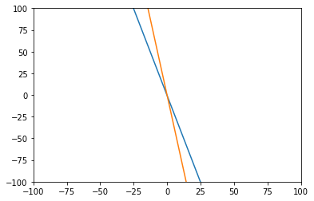

```python
import matplotlib.pyplot as plt
import numpy as np

a1 = float(input("Enter value of a1: "))
b1 = float(input("Enter value of b1: "))
c1 = float(input("Enter value of c1: "))

a2 = float(input("Enter value of a2: "))
b2 = float(input("Enter value of b2: "))
c2 = float(input("Enter value of c2: "))

if a1 * b2 != a2 * b1:
    print("Intersecting lines")

if (a1/a2) == (b1/b2) and (b1/b2) == (c1/c2):
    print("Overlapping lines")

if (a1/a2) == (b1/b2) and (b1/b2) != (c1/c2):
    print("Parallel lines")
fig,ax = plt.subplots()
x = np.linspace(-100.,100.)
ax.set_xlim((-100.,100.))
ax.set_ylim((-100.,100.))

def addToplot(slope, intercept):
    ax.plot(x,slope*x+intercept)


addToplot(-a1/b1, -c1/a1)
addToplot(-a2/b2, -c2/a2)
plt.show()
```

### Question 3 **[30 pts]**:

Write a code for a Number Guessing Game. The code assigns a random integer number from a given interval to a varible, then asks the user to make a guess to find that number.

Do not forget to check the validity of the selected number:

- Is it an integer?
- Is it an integer that lies in the given range?

**a)** **[10 pts]** Follow these steps to implement a simple version of the game:

- The code assigns a random integer number between 0 and 100 to a variable.
- The code gives the user only one chance to guess that number.
- The output of the code should be either 'correct' or 'wrong'.

Hint: Use the `random` module to generate a pseudo-random number.

```python
import random

inclusive_range = (1, 100)

print("Guess my target number that is between %i and %i (inclusive).\n"
      % inclusive_range)
target = random.randint(*inclusive_range)

txt = input("Your guess: " )
answer=int(txt)
if answer == target:
        print(" Correct")
else:
        print("  Wrong")
```

```
Guess my target number that is between 1 and 100 (inclusive).
```

```
  Wrong
```

**b)** **[10 pts]** Since it is difficult to guess a number in one try, let us give chances and clues.

With unlimited trials and a random integer number in the inclusive range from 0 to 100, the code will compare the first guess with the random number and tell the user if the random number is lower or higher than the user's guess, and so on untill the user correctly guesses the random integer number.

```python
import random

inclusive_range = (1, 100)

print("Guess my target number that is between %i and %i (inclusive).\n"
      % inclusive_range)
target = random.randint(*inclusive_range)
answer, i = None, 0
while answer != target:
    i += 1
    txt = input("Your guess(%i): " % i)
    try:
        answer = int(txt)
    except ValueError:
        print("  I don't understand your input of '%s' ?" % txt)
        continue
    if answer < inclusive_range[0] or answer > inclusive_range[1]:
        print("  Out of range!")
        continue
    if answer == target:
        print(" Correct")
        break
    if answer < target: print("  Too low.")
    if answer > target: print("  Too high.")

print("\nThanks for playing.")
```

```
Guess my target number that is between 1 and 100 (inclusive).
```

```
  Too high.
```

```
  Too low.
```

```
  Too high.
```

**c)** **[10 pts]** Let us develop a better version of the program by limiting the number of chances for guessing the random number based on the interval's boundaries.

Start with asking the user to enter two numbers, being the lower and upper bounds of the interval from which the random number will be selected. After the application chooses the random number based on the entered boundaries, find and print the number of attempts given to the user by computing the square root of the difference between the lower and upper bounds.

Notably, the lower-bound value must be at least 1, and the upper-bound value must be higher than the lower-bound one.

```python
from random import randint
import math
upper_bound = int(input("Upper bound of random number:"))
lower_bound = int(input("Lower bound of random number:"))
target= randint(lower_bound,upper_bound)
attempts = round(math.sqrt(upper_bound-lower_bound))
for i in range(attempts):
    print("Number of chances available to guess", (attempts-i))
    guess = int(input("Your guess:"))
    if target == guess:
        print(" Correct")
        break
    elif target > guess:
        print(" Random number is higher than guess")
    else:
        print("Random number is lower than guess")
```

```
Number of chances available to guess 9
```

```
 Random number is higher than guess
Number of chances available to guess 8
```

### Question 4 **[30 pts]**:

Write a code for The Hangman Game. In this game, the user only enters the number of letters existing in that word, and the computer tries to guess them based on a fixed number of attempts. The game ends if the computer correctly guessed all the letters in order or used all of the given attempts.

```python
import random
import time
print("** Welcome to Hangman game! **")
num_chrs = int(input("\nEnter number of characters in the word (1-15): "))
while num_chrs < 1 or num_chrs > 15:
    print("Word length should be from 1 to 15. Try again.")
    num_chrs = int(input("\nEnter number of characters in the word (1-15): "))

words = ['a','i', 'it','is','men','bus','dumb','best','dress','beans','topaz'
         'father','purple','climate','kingdom','election','accurate',
         'nutrition','crocodile','television','blueberry','uranus'
         'intelligent','abbreviation','trigonometry','national','intercaste'
         'extraordinary','discrimination','accountability','acknowledgement']

while True:
    word = random.choice(words)
    if len(word) == num_chrs:
        break

print("\nRandom word created with length",num_chrs)
guessed = ''
num_turns = 15
comp_guesses = []
print("\nNow computer will guess all the characters of the word with",num_turns,"chances.\n")
input("\nPress Enter to start! ")

while num_turns > 0:

    while True:
        comp_guess = random.choice(['a','b','c','d','e','f','g','h',
                                      'i','j','k','l','m','n','o','p',
                                     'q','r','s','t','u','v','w','x','y','z'])

        if comp_guess not in comp_guesses:

            comp_guesses.append(comp_guess)
            break

    print("\nComputer guess:",comp_guess)

    if comp_guess not in word:
        num_turns -= 1
        time.sleep(1)
        print("Wrong guess!")
        time.sleep(1)
        print(num_turns, 'chances left\n')
        if num_turns == 0:
            print("Computer Loose!")
            print("\nThe word is:", word)
            break

    else:
        guessed += comp_guess
        time.sleep(1)
        print('Correct guess!\n')

    time.sleep(1)

    failed = 0
    for char in word:
        if char in guessed:
            print(char, end = ' ')
        else:
            print('_', end = ' ')
            failed += 1
    print()

    if failed == 0:
        print("\nComputer win!")
        print("\nThe word is:", word)
        break
    print("__________")
    time.sleep(2)
```

```
** Welcome to Hangman game! **
```

```
Random word created with length 5

Now computer will guess all the characters of the word with 15 chances.
```

```
Computer guess: b
Correct guess!

b _ _ _ _
__________

Computer guess: q
Wrong guess!
14 chances left

b _ _ _ _
__________

Computer guess: o
Wrong guess!
13 chances left

b _ _ _ _
__________

Computer guess: c
Wrong guess!
12 chances left

b _ _ _ _
__________

Computer guess: v
Wrong guess!
11 chances left

b _ _ _ _
__________

Computer guess: s
Correct guess!

b _ _ _ s
__________

```

[output cut: 68 more lines]

```

Computer guess: i
Wrong guess!
1 chances left

b _ _ n s
__________

Computer guess: f
Wrong guess!
0 chances left

Computer Loose!

The word is: beans
```

#### This is the end of assignment 1